# Midterm Assignment

Tom Grant

15/11/2020

# Import and Display the data

```r
require("kableExtra")
require("fma")
myts <- read.csv('/Users/ThomasGrant/Downloads/pop.csv')
kbl(myts)
```

| Year | Scotland.population | Great.Britain.population | England.population | United.Kingdom.population | England.and.Wales.population | Northern.Ireland.population | Wales.population |
| --- | --- | --- | --- | --- | --- | --- | --- |
| 1971 | 5235600 | 54387600 | 46411700 | 55928000 | 49152000 | 1540400 | 2740300 |
| 1972 | 5230600 | 54557700 | 46571900 | 56096700 | 49327100 | 1539000 | 2755200 |
| 1973 | 5233900 | 54692900 | 46686200 | 56222900 | 49459000 | 1530000 | 2772800 |
| 1974 | 5240800 | 54708700 | 46682700 | 56235600 | 49467900 | 1526900 | 2785200 |
| 1975 | 5232400 | 54702200 | 46674400 | 56225700 | 49469800 | 1523500 | 2795400 |
| 1976 | 5233400 | 54692600 | 46659900 | 56216100 | 49459200 | 1523500 | 2799300 |
| 1977 | 5226200 | 54666600 | 46639800 | 56189900 | 49440400 | 1523300 | 2800600 |
| 1978 | 5212300 | 54654800 | 46638200 | 56178000 | 49442500 | 1523200 | 2804300 |
| 1979 | 5203600 | 54711800 | 46698100 | 56240100 | 49508200 | 1528300 | 2810100 |
| 1980 | 5193900 | 54796900 | 46787200 | 56329700 | 49603000 | 1532800 | 2815800 |
| 1981 | 5180200 | 54814500 | 46820800 | 56357500 | 49634300 | 1543000 | 2813500 |
| 1982 | 5164500 | 54746200 | 46777300 | 56290700 | 49581600 | 1544500 | 2804300 |
| 1983 | 5148100 | 54765100 | 46813700 | 56315700 | 49617000 | 1550600 | 2803300 |
| 1984 | 5138900 | 54852000 | 46912400 | 56409300 | 49713100 | 1557300 | 2800700 |
| 1985 | 5127900 | 54988600 | 47057400 | 56554000 | 49860700 | 1565400 | 2803400 |
| 1986 | 5111800 | 55110300 | 47187600 | 56683800 | 49998600 | 1573500 | 2810900 |
| 1987 | 5099000 | 55222000 | 47300400 | 56804000 | 50123000 | 1582000 | 2822600 |
| 1988 | 5077400 | 55331000 | 47412300 | 56916400 | 50253600 | 1585400 | 2841200 |
| 1989 | 5078200 | 55486000 | 47552700 | 57076500 | 50407800 | 1590400 | 2855200 |
| 1990 | 5081300 | 55641900 | 47699100 | 57237500 | 50560600 | 1595600 | 2861500 |
| 1991 | 5083300 | 55831400 | 47875000 | 57438700 | 50748000 | 1607300 | 2873000 |
| 1992 | 5085600 | 55961300 | 47998000 | 57584500 | 50875600 | 1623300 | 2877700 |
| 1993 | 5092500 | 56078300 | 48102300 | 57713900 | 50985900 | 1635600 | 2883600 |
| 1994 | 5102200 | 56218400 | 48228800 | 57862100 | 51116200 | 1643700 | 2887400 |
| 1995 | 5103700 | 56375700 | 48383500 | 58024800 | 51272000 | 1649100 | 2888500 |
| 1996 | 5092200 | 56502600 | 48519100 | 58164400 | 51410400 | 1661800 | 2891300 |
| 1997 | 5083300 | 56643000 | 48664800 | 58314200 | 51559600 | 1671300 | 2894900 |
| 1998 | 5077100 | 56797200 | 48820600 | 58474900 | 51720100 | 1677800 | 2899500 |
| 1999 | 5072000 | 57005400 | 49032900 | 58684400 | 51933500 | 1679000 | 2900600 |
| 2000 | 5062900 | 57203100 | 49233300 | 58886100 | 52140200 | 1682900 | 2906900 |
| 2001 | 5064200 | 57424200 | 49449700 | 59113000 | 52360000 | 1688800 | 2910200 |
| 2002 | 5066000 | 57668100 | 49679300 | 59365700 | 52602100 | 1697500 | 2922900 |
| 2003 | 5068500 | 57931700 | 49925500 | 59636700 | 52863200 | 1704900 | 2937700 |
| 2004 | 5084300 | 58236300 | 50194600 | 59950400 | 53152000 | 1714000 | 2957400 |
| 2005 | 5110200 | 58685500 | 50606000 | 60413300 | 53575300 | 1727700 | 2969300 |
| 2006 | 5133100 | 59084000 | 50965200 | 60827100 | 53950900 | 1743100 | 2985700 |
| 2007 | 5170000 | 59557400 | 51381100 | 61319100 | 54387400 | 1761700 | 3006300 |
| 2008 | 5202900 | 60044600 | 51815900 | 61823800 | 54841700 | 1779200 | 3025900 |
| 2009 | 5231900 | 60467200 | 52196400 | 62260500 | 55235300 | 1793300 | 3038900 |
| 2010 | 5262200 | 60954600 | 52642500 | 62759500 | 55692400 | 1804800 | 3050000 |
| 2011 | 5299900 | 61470800 | 53107200 | 63285100 | 56170900 | 1814300 | 3063800 |
| 2012 | 5313600 | 61881400 | 53493700 | 63705000 | 56567800 | 1823600 | 3074100 |
| 2013 | 5327700 | 62275900 | 53865800 | 64105700 | 56948200 | 1829700 | 3082400 |
| 2014 | 5347600 | 62756300 | 54316600 | 64596800 | 57408700 | 1840500 | 3092000 |
| 2015 | 5373000 | 63258400 | 54786300 | 65110000 | 57885400 | 1851600 | 3099100 |
| 2016 | 5404700 | 63785900 | 55268100 | 65648100 | 58381200 | 1862100 | 3113200 |
| 2017 | 5424800 | 64169400 | 55619400 | 66040200 | 58744600 | 1870800 | 3125200 |
| 2018 | 5438100 | 64553900 | 55977200 | 66435600 | 59115800 | 1881600 | 3138600 |

This is the initial stage of the project where I add the population database to my R code.

# Break the original dataset into the desired groups

```r
mytsScotland<-ts(myts$Scotland.population, start="1971",end="2018",frequency=1)
mytsEngland<-ts(myts$England.population, start="1971",end="2018",frequency=1)
mytsNorthIreland<-ts(myts$Northern.Ireland.population, start="1971",end="2018",frequency=1)
mytsWales<-ts(myts$Wales.population, start="1971",end="2018",frequency=1)
```

Using the ts() function the the myts dataset is broken down into the four countries which we are analysing, England, Wales, Scotland and Northern Ireland.

### Visualizations of each country’s data

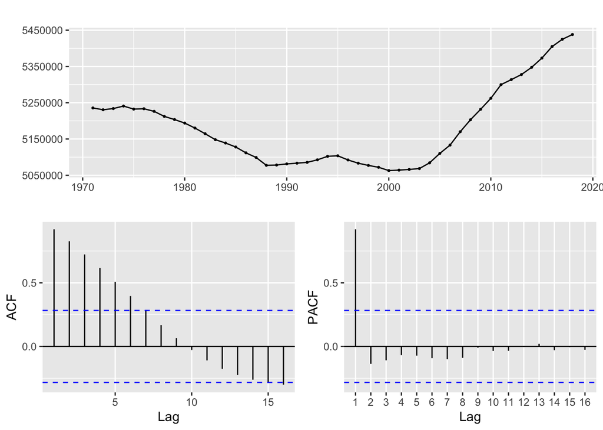

```r
ggtsdisplay(mytsScotland)
```

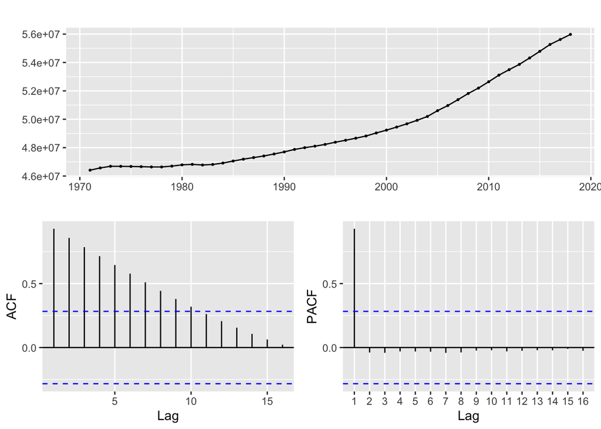

```r
ggtsdisplay(mytsEngland)
```

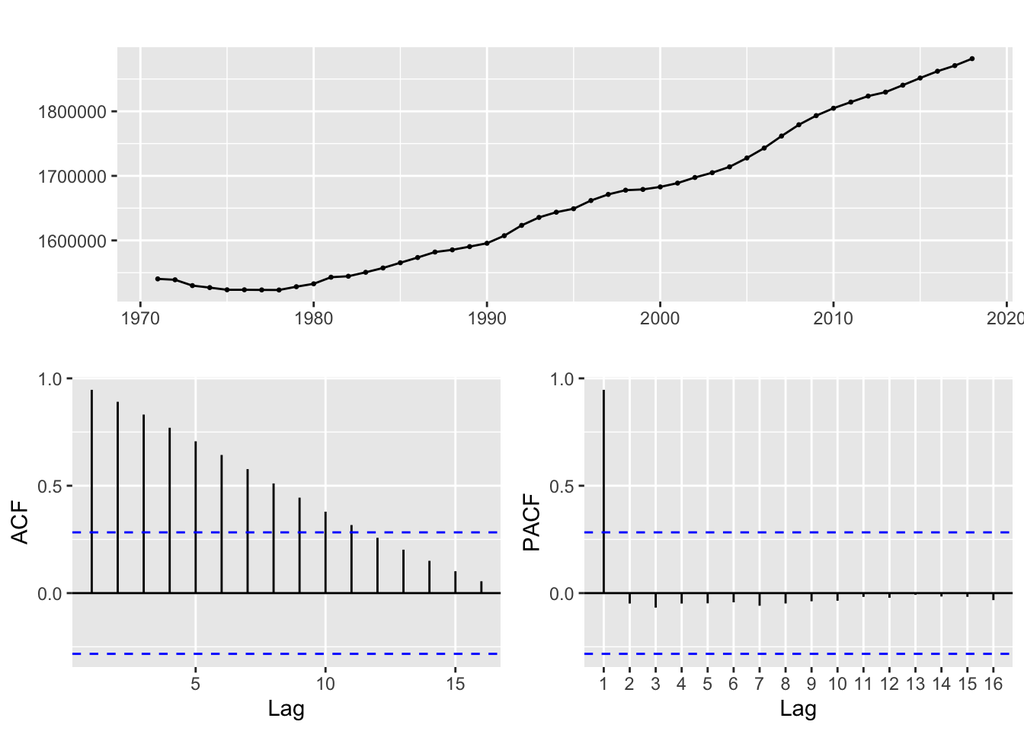

```r
ggtsdisplay(mytsNorthIreland)
```

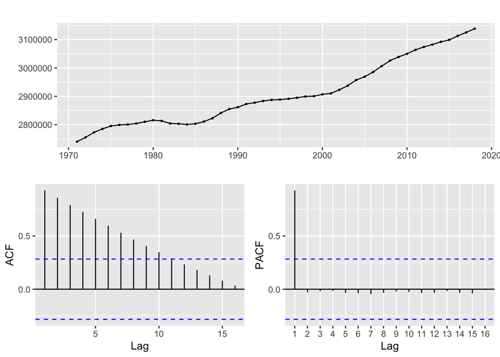

```r
ggtsdisplay(mytsWales)
```

Using the ggtsdisplay() function we can see the shape of the time series and analyse the ACF and PACF graphs to see if there is a cyclical component to the data. The ACF and PACF in each of these four datasets demonstrates that there is not a cyclical component to the data. If there was a cyclical component to the data we would see a regular spike in both of those graphs. This allows us to eliminate the SHW+ and SHW+ algorithms from our search for the best algorithms to predict the populations of Scotland, England, Northern Ireland and Wales. The shape of the time series also indicates that in the datasets that there is a trend component. indicating that the DES algorithm will be the most suitable.

# Calculate the best algorithm for the datasets

Using both the Simple Exponential Smoothing Algorithm:

Init: $F_1=y_1$ and choose $0<\alpha<1$
$$F_{t+1}=F_t+\alpha(y_t-F_t)$$

and the Double Exponential Smoothing Algorithm:

Init $L_1=y_1$ $b_1=y_2-y_1$ $F_1=y_1$

and choose $0<\alpha<1$, $0<\beta<1$
$$L_t = \alpha y_t + (1-\alpha)(L_{t-1}+b_{t-1})$$
$$b_t = \beta(L_t-L_{t-11})+(1-\beta)b_{t-1}$$
$$F_{t+1} = L_t+b_t$$
We can calculate the sums of square error for each algorithm. The sum of square errors is the cumulative square difference between the forecasted figures and the actual figures. To choose the best algorithm to predict the next two values of the datasets.
$$SSE = \sum_{i=1}^{n} (F_i-y_i)^2$$
$n$ = the number of observations.

```r
EnglandSSE <- matrix(c('SES <- ','DES <- ',HoltWinters(mytsEngland,beta = FALSE, gamma = FALSE )$SSE,HoltWinters(mytsEngland,gamma = FALSE)$SSE), nrow = 2, byrow = FALSE)
ScotlandSSE <- matrix(c('SES <- ','DES <- ',HoltWinters(mytsScotland,beta = FALSE, gamma = FALSE )$SSE,HoltWinters(mytsScotland,gamma = FALSE)$SSE), nrow = 2, byrow = FALSE)
WalesSSE <- matrix(c('SES <- ','DES <- ', HoltWinters(mytsWales,beta = FALSE, gamma = FALSE )$SSE,HoltWinters(mytsWales,gamma = FALSE)$SSE), nrow = 2, byrow = FALSE)
NorthIrelandSSE <- matrix(c('SES <- ','DES <- ', HoltWinters(mytsNorthIreland,beta = FALSE, gamma = FALSE )$SSE,HoltWinters(mytsNorthIreland,gamma = FALSE)$SSE), nrow = 2, byrow = FALSE)
```

We will now use the kbl() function to check our figures and see what the best algorithm is.

```r
kbl(EnglandSSE)
```

| SES <- | 3063537970508.5 |
| --- | --- |
| DES <- | 118533920000 |

```r
kbl(ScotlandSSE)
```

| SES <- | 12985348622.0865 |
| --- | --- |
| DES <- | 2984065604.16181 |

```r
kbl(WalesSSE)
```

| SES <- | 5375103694.85103 |
| --- | --- |
| DES <- | 947966577.452467 |

```r
kbl(NorthIrelandSSE)
```

| SES <- | 3968207744.35607 |
| --- | --- |
| DES <- | 590323223.40245 |

# Use The DES algorithm to calculate the populations for 2020

The SSE Check has proven that the DES is a better algorithm for predicting these four algorithms as they have trend components.

Using the DES Algorithm we calculate the population for the next two years:

```r
forecast(HoltWinters(mytsNorthIreland, gamma = FALSE), h=2)
```

```
##      Point Forecast   Lo 80   Hi 80   Lo 95   Hi 95
## 2019        1892030 1887408 1896652 1884961 1899099
## 2020        1902460 1893020 1911900 1888022 1916897
```

```r
forecast(HoltWinters(mytsWales, gamma = FALSE), h=2)
```

```
##      Point Forecast   Lo 80   Hi 80   Lo 95   Hi 95
## 2019        3151837 3145955 3157719 3142842 3160833
## 2020        3165107 3152578 3177636 3145945 3184268
```

```r
forecast(HoltWinters(mytsScotland, gamma = FALSE), h=2)
```

```
##      Point Forecast   Lo 80   Hi 80   Lo 95   Hi 95
## 2019        5453202 5442790 5463614 5437279 5469126
## 2020        5468304 5446899 5489710 5435568 5501041
```

```r
forecast(HoltWinters(mytsEngland, gamma = FALSE), h=2)
```

```
##      Point Forecast    Lo 80    Hi 80    Lo 95    Hi 95
## 2019       56335000 56269462 56400538 56234769 56435231
## 2020       56692800 56546253 56839347 56468676 56916924
```

These forecasts assume that the following data follows the trend exactly. The hi and lo columns finds the variance of the previous observations and uses them to calculate confidence intervals.